# Lab 7.4 - Using themes

# Plot themes

By now you may have already seen that `ggplot2` has its own *style*: font type and font size, axis proportions, light grey background and white grid… Characteristics that make the plots generated by this function recognisable. These default options (called `theme_grey()`), is the signature ggplot2 theme with a light grey background and white gridlines. The theme is designed to put the data forward while supporting comparisons. We can still see the gridlines to aid in the judgement of position, but they have little visual impact and we can easily ‘tune’ them out. The grey background gives the plot a similar typographic colour to the text, ensuring that the graphics fit in with the flow of a document without jumping out with a bright white background. Finally, the grey background creates a continuous field of colour which ensures that the plot is perceived as a single visual entity. This theme is of course customisable, and in fact the default style is not particularly beutiful. We can customize almost anything, though that implies becoming familiar with a large number of instructions. To make it easier, ggplot contains a number of predefined styles, which can be activated at will:

## Complete themes

Each one has it’s own style and it’s up to you to decide which one is closer to your needs. Don’t worry, even after assigning a theme we can keep customizing. In fact, these default themes are good starting point towards our own themes. Just invoke one of them at the end of the `ggplot` call and we are done.

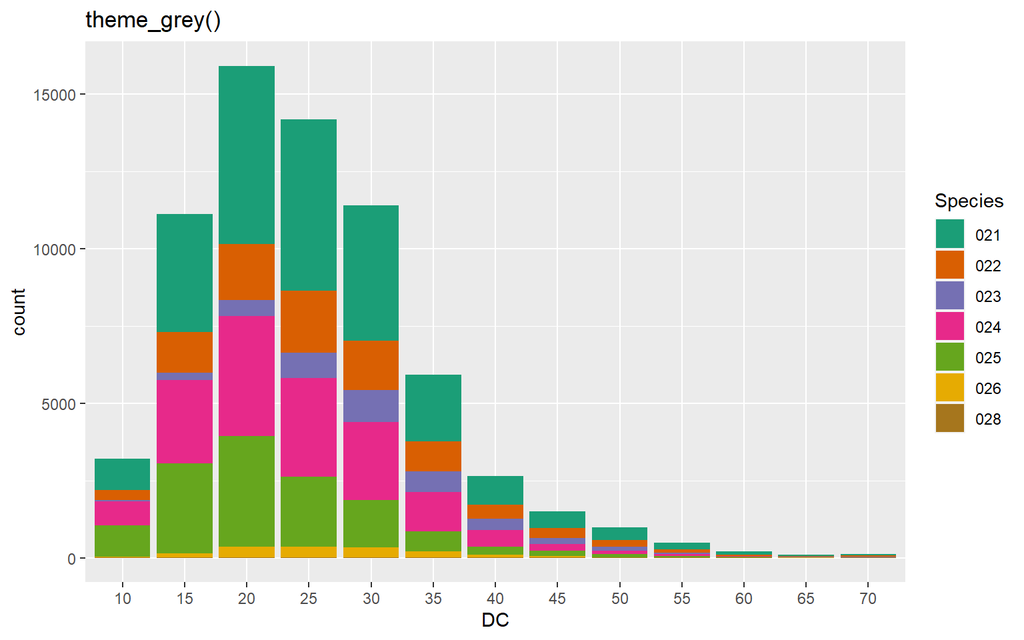

```r
ggplot(pines) + geom_bar(aes(x = DC, fill = Species)) + scale_fill_brewer(type = "qual",
    palette = "Dark2") + theme_grey() + ggtitle("theme_grey()")
```

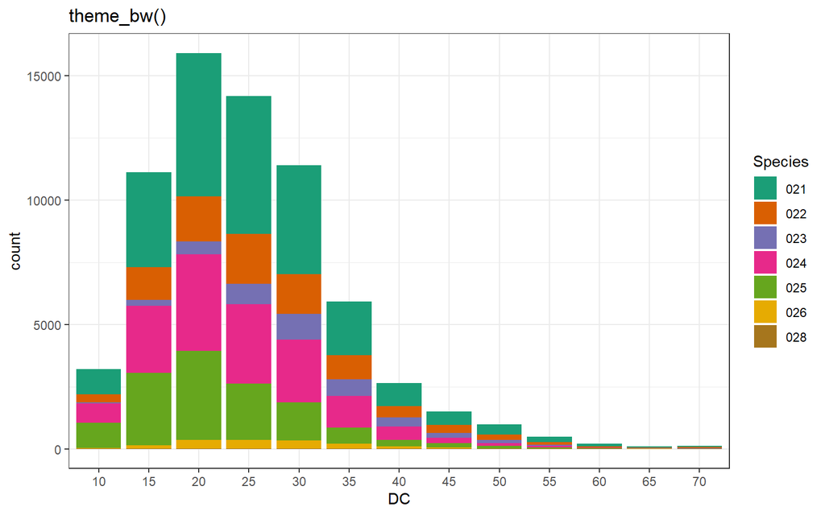

```r
ggplot(pines) + geom_bar(aes(x = DC, fill = Species)) + scale_fill_brewer(type = "qual",
    palette = "Dark2") + theme_bw() + ggtitle("theme_bw()")
```

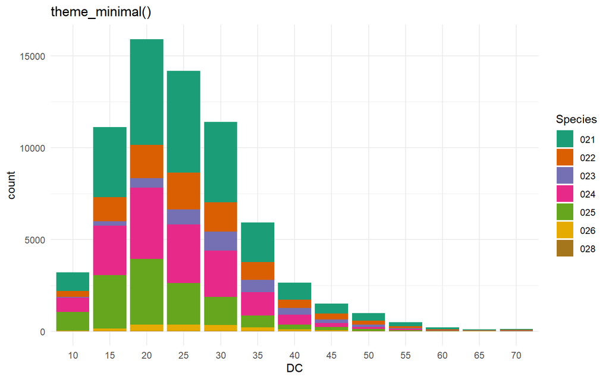

```r
ggplot(pines) + geom_bar(aes(x = DC, fill = Species)) + scale_fill_brewer(type = "qual",
    palette = "Dark2") + theme_minimal() + ggtitle("theme_minimal()")
```

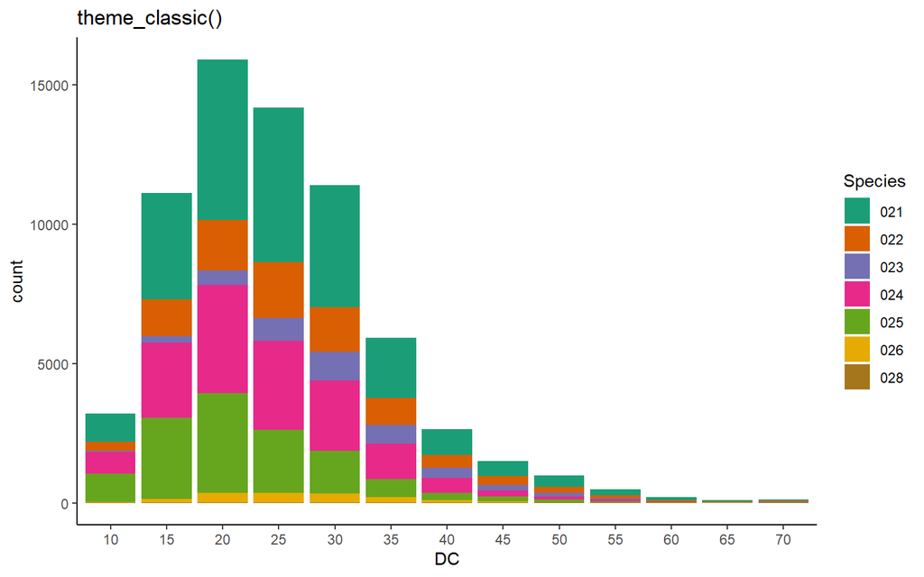

```r
ggplot(pines) + geom_bar(aes(x = DC, fill = Species)) + scale_fill_brewer(type = "qual",
    palette = "Dark2") + theme_classic() + ggtitle("theme_classic()")
```

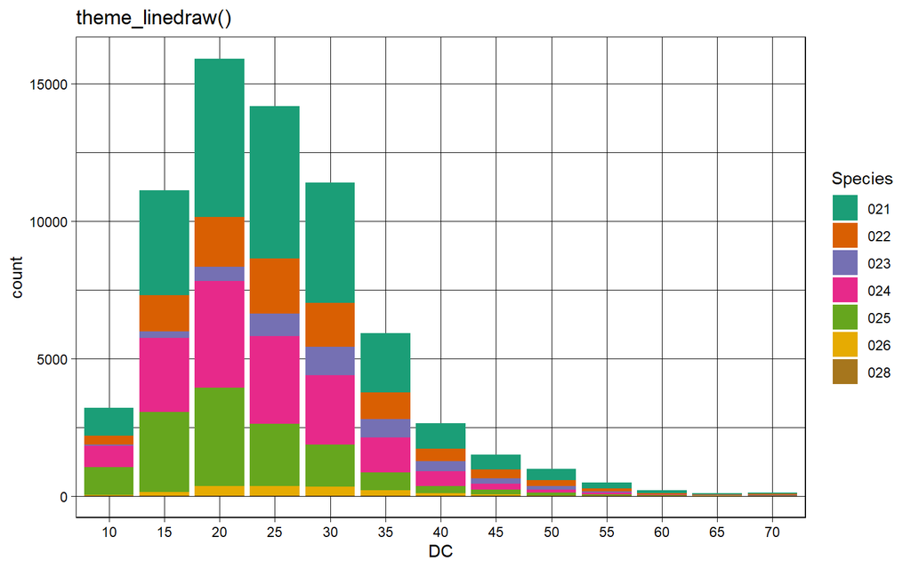

```r
ggplot(pines) + geom_bar(aes(x = DC, fill = Species)) + scale_fill_brewer(type = "qual",
    palette = "Dark2") + theme_linedraw() + ggtitle("theme_linedraw()")
```

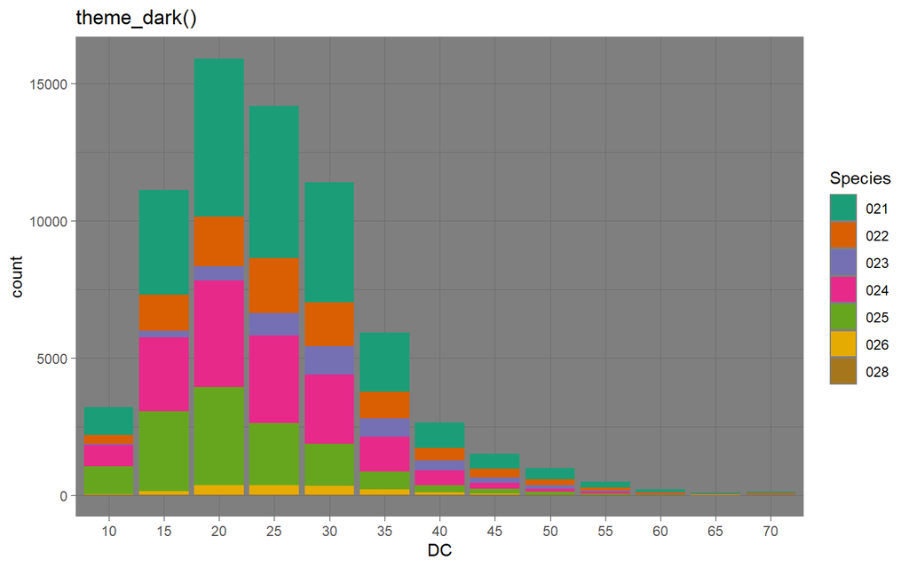

```r
ggplot(pines) + geom_bar(aes(x = DC, fill = Species)) + scale_fill_brewer(type = "qual",
    palette = "Dark2") + theme_dark() + ggtitle("theme_dark()")
```

## Getting additional themes

Same as color scales, several developers invested some time to create specific themes. The package `ggthemes` is a good example. It includes a collection of predifined themes *mimicking* the style of some of the most famous journals.

You can take a quick tour in https://yutannihilation.github.io/allYourFigureAreBelongToUs/ggthemes/.

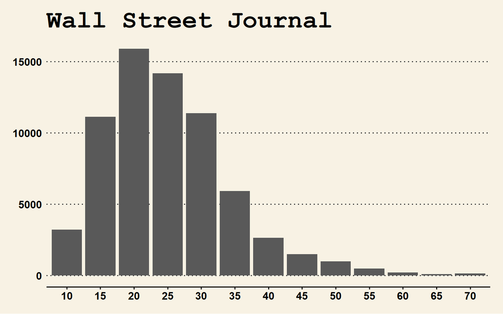

```r
library(ggthemes)

ggplot(pines, aes(x = DC)) + geom_bar() + theme_wsj() + ggtitle("Wall Street Journal")
```

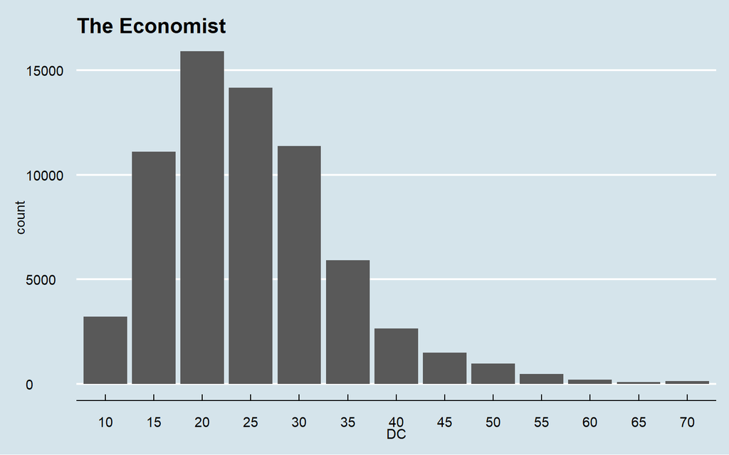

```r
ggplot(pines, aes(x = DC)) + geom_bar() + theme_economist() + ggtitle("The Economist")
```

## Modifying a theme

Despite of the wide array of themes that we can get, it is normally the case we want to set up our own theme. That is particularly important when we are involved in a scientific document and we need to produce similar figures in terms of style. ggplot2 allows us to go one step further and explicitly define all plot elements.

To do this, we must define a theme() layer inside which we specify the elements to be modified. These elements have 4 types, each of which contains different parameters to customise.

- `element_text()` is used to include labels, texts, titles, and any text element. Within it we can define the font (`family`), `face` (typeface), `colour`, `size` and `lineheight`, among others. More details on the parameters can be found in `vignette("ggplot2-specs")`.

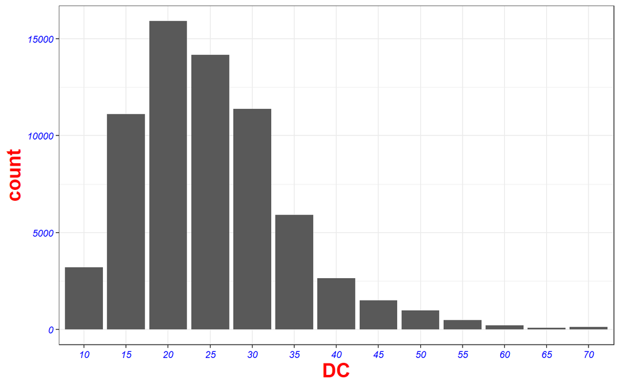

```r
ggplot(pines) +
    geom_bar(aes(x= DC)) +
    theme_bw() +
    theme(axis.title = element_text(face = "bold", color = "red", size = 18),  # We modify the titles
          axis.text = element_text(face = "italic", color = "blue"))           #We modify the axes)
```

- `element_line()` draws lines defined by ``colour`, `size`, `linetype` and `lineheight`, among others.

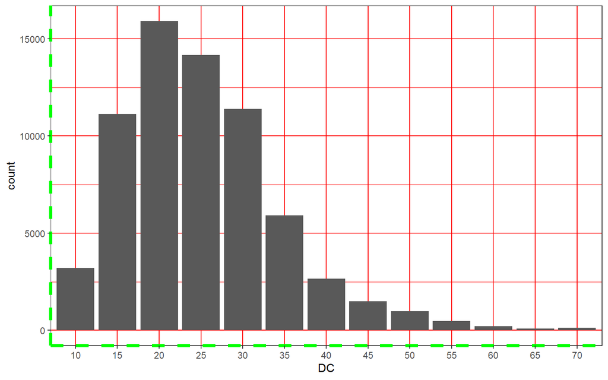

```r
ggplot(pines) + geom_bar(aes(x = DC)) + theme_bw() + theme(axis.line = element_line(color = "green",
    linetype = "dashed", size = 1.5), panel.grid = element_line(color = "red"))
```

- `element_rect()` draws rectangles, mostly used for backgrounds, parameterised by `fill` colour and border `colour`, `size` and `linetype`.

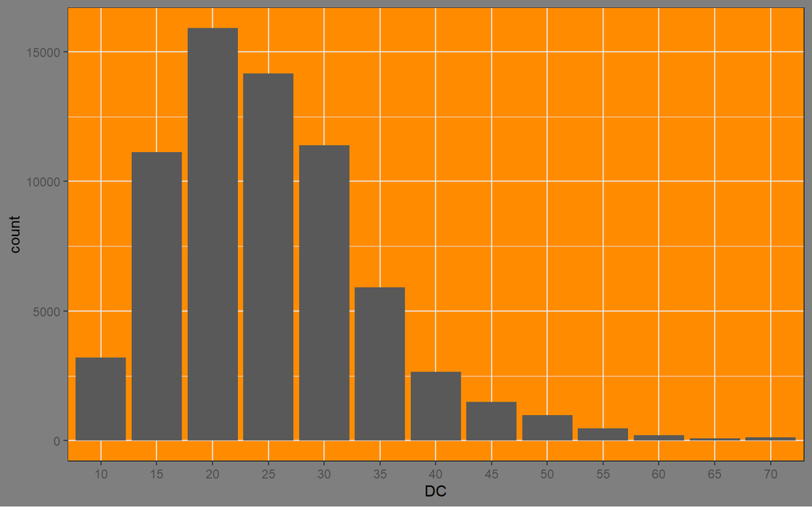

```r
ggplot(pines) + geom_bar(aes(x = DC)) + theme_bw() + theme(plot.background = element_rect(fill = "grey50",
    colour = NA), panel.background = element_rect(fill = "dark orange"))
```

- `element_blank()` draws nothing. Use this if you don’t want anything drawn, and no space allocated for that element. The following example uses `element_blank()` to progressively suppress the appearance of elements we’re not interested in. Notice how the plot automatically reclaims the space previously used by these elements: if you don’t want this to happen (perhaps because they need to line up with other plots on the page), use `colour = NA, fill = NA` to create invisible elements that still take up space.

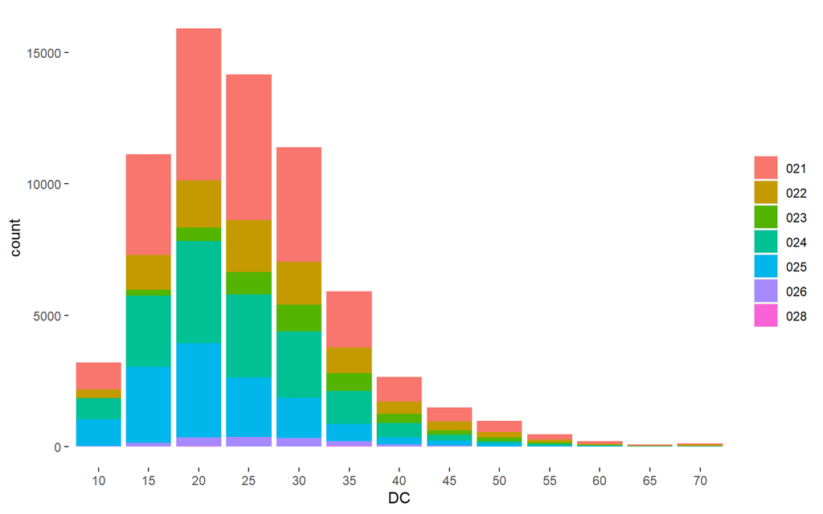

```r
ggplot(pines) +
    geom_bar(aes(x= DC, fill = Species)) +
    theme(panel.grid.minor = element_blank(),    # we delete the grid lines
          panel.background = element_blank(),    # we delete the background
          legend.title = element_blank())        # we delete legend title
```

::: exercise :::

**EXERCISE 1**

Modify the theme of the plot created in previous labs to make it more aesthetically pleasing, according to your own criteria. You must at least modify one element with `element_text()`, one with `element_line()`, another with `element_rect()`, and one with `element_rect()`

:::

# To know more: theme elements

## Plot elements

Some elements affect the plot as a whole:

| Element | Setter | Description |
| --- | --- | --- |
| plot.background | `element_rect()` | plot background |
| plot.title | `element_text()` | plot title |
| plot.margin | `margin()` | margins around plot |

`plot.background` draws a rectangle that underlies everything else on the plot. By default, ggplot2 uses a white background which ensures that the plot is usable wherever it might end up (e.g. even if you save as a png and put on a slide with a black background). When exporting plots to use in other systems, you might want to make the background transparent with `fill = NA`. Similarly, if you’re embedding a plot in a system that already has margins you might want to eliminate the built-in margins. Note that a small margin is still necessary if you want to draw a border around the plot.

## Axis elements

The axis elements control the apperance of the axes:

| Element | Setter | Description |
| --- | --- | --- |
| axis.line | `element_line()` | line parallel to axis (hidden in default themes) |
| axis.text | `element_text()` | tick labels |
| axis.text.x | `element_text()` | x-axis tick labels |
| axis.text.y | `element_text()` | y-axis tick labels |
| axis.title | `element_text()` | axis titles |
| axis.title.x | `element_text()` | x-axis title |
| axis.title.y | `element_text()` | y-axis title |
| axis.ticks | `element_line()` | axis tick marks |
| axis.ticks.length | `unit()` | length of tick marks |

Note that `axis.text` (and `axis.title`) comes in three forms: `axis.text`, `axis.text.x`, and `axis.text.y`. Use the first form if you want to modify the properties of both axes at once: any properties that you don’t explicitly set in `axis.text.x` and `axis.text.y` will be inherited from `axis.text`.

## Legend elements

The legend elements control the apperance of all legends. You can also modify the appearance of individual legends by modifying the same elements in `guide_legend()` or `guide_colourbar()`.

| Element | Setter | Description |
| --- | --- | --- |
| legend.background | `element_rect()` | legend background |
| legend.key | `element_rect()` | background of legend keys |
| legend.key.size | `unit()` | legend key size |
| legend.key.height | `unit()` | legend key height |
| legend.key.width | `unit()` | legend key width |
| legend.margin | `unit()` | legend margin |
| legend.text | `element_text()` | legend labels |
| legend.text.align | 0–1 | legend label alignment (0 = right, 1 = left) |
| legend.title | `element_text()` | legend name |
| legend.title.align | 0–1 | legend name alignment (0 = right, 1 = left) |

## Panel elements

Panel elements control the appearance of the plotting panels:

| Element | Setter | Description |
| --- | --- | --- |
| panel.background | `element_rect()` | panel background (under data) |
| panel.border | `element_rect()` | panel border (over data) |
| panel.grid.major | `element_line()` | major grid lines |
| panel.grid.major.x | `element_line()` | vertical major grid lines |
| panel.grid.major.y | `element_line()` | horizontal major grid lines |
| panel.grid.minor | `element_line()` | minor grid lines |
| panel.grid.minor.x | `element_line()` | vertical minor grid lines |
| panel.grid.minor.y | `element_line()` | horizontal minor grid lines |
| aspect.ratio | numeric | plot aspect ratio |

The main difference between `panel.background` and `panel.border` is that the background is drawn underneath the data, and the border is drawn on top of it. For that reason, you’ll always need to assign `fill = NA` when overriding `panel.border`.

You can find more information on theme elements in the [ggplot2 website](https://ggplot2.tidyverse.org/reference/theme.html)